# multivariate_plot.Rに対応したR Notebook

## 第8章の内容

### データの準備

まずは第6章までと同じデータを読み込む

```r
###For chapter 08
phyto_metadata <- readRDS("phyto_metadata.obj")
species_ryuko_data <- readRDS("phyto_ryuko_data.obj")
metadata_ecoplate <- readRDS("metadata_ecopl.obj")
summary_ecoplate <- readRDS("summary_ecopl.obj")
species_richness <- apply(species_ryuko_data > 0, 1, sum) #種数を計算
total_abundance <- apply(species_ryuko_data, 1, sum) #総個体数を計算
```

エコプレートで使用されている31種類の有機炭素基質の名前リストをベクトルとして用意しておく

```r
substrate_name <- c("Pyruvic-Acid-Methyl-Ester", "Tween-40", "Tween-80","alpha-Cyclodextrin", "Glycogen", "D-Cellobiose","alpha-D-Lactose", "beta-Methyl-D-Glucoside", "D-Xylose", "i-Erythritol", "D-Mannitol","N-Acetyl-D-Glucosamine", "D-Glucosaminic-Acid", "Glucose-1-Phosphate","alpha-Glycerol-Phosphate","D-Galactonic-Acid-gamma-Lactone", "D-Galacturonic-Acid", "2-Hydroxy-Benzoic-Acid", "4-Hydroxy-Benzoic-Acid", "gamma-Hydroxybutyric-Acid", "Itaconic-Acid", "alpha-Ketobutyric-Acid", "D-Malic-Acid", "L-Arginine", "L-Asparagine", "L-Phenylalanine", "L-Serine", "L-Threonine", "Glycyl-L-Glutamic-Acid", "Phenylethyl-amine", "Putrescine")

substrate_jpn <- c("Pyruvic-Acid-Methyl-Ester", "Tween-40", "Tween-80","alpha-Cyclodextrin", "Glycogen", "D-Cellobiose","alpha-D-Lactose", "beta-Methyl-D-Glucoside", "D-Xylose", "i-Erythritol", "D-Mannitol","N-Acetyl-D-Glucosamine", "D-Glucosaminic-Acid", "Glucose-1-Phosphate","alpha-Glycerol-Phosphate","D-Galactonic-Acid-gamma-Lactone", "D-Galacturonic-Acid", "2-Hydroxy-Benzoic-Acid", "4-Hydroxy-Benzoic-Acid", "gamma-Aminobutyric-acid", "Itaconic-Acid", "alpha-Ketobutyric-Acid", "D-Malic-Acid", "L-Arginine", "L-Asparagine", "L-Phenylalanine", "L-Serine", "L-Threonine", "Glycyl-L-Glutamic-Acid", "Phenylethyl-amine", "Putrescine")
```

パッケージの読み込み

```r
library(rgl)
library(vegan)
```

### 8.1 多変量と次元削減

#### 線形回帰の可視化(復習)

エコプレートデータの一部を使う

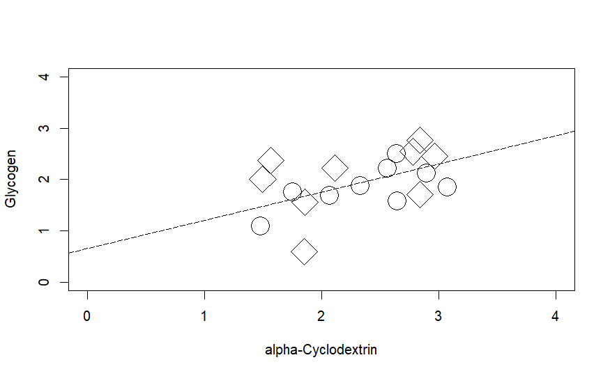

```r
#散布図の描画
plot(
  s05 ~ s04, data = summary_ecoplate, #モデル式(Y ~ X):エコプレートデータの4番目と5番目の基質に注目
  type = "p", #グラフのタイプの指定, pは散布図
  cex = 3, #データの描画のマークの大きさの指定
  pch = c(1, 5)[as.factor(metadata_ecoplate$treatment)], #処理(treatment)の違いをマークの種類の違いに変換
  xlab = substrate_name[4], #基質４の名前をx軸名にする
  ylab = substrate_name[5], #基質5の名前をy軸名にする
  xlim = c(0, 4), #x軸の描画範囲(ただしこのHTMLでは縦横比aspの指定と両立しない)
  ylim = c(0, 4) #y軸の描画範囲
  #,asp = 1.0　　#縦横比の指定(ここでは指定しない)
)
#線形回帰分析
model01 <- lm(s05 ~ s04, data = summary_ecoplate)
#回帰直線の追加
abline(model01, lty = 5)
```

#### 次元削減の可視化

上の線形回帰に使ったのと同じデータを使う

```r
#散布図
plot(
  s05 ~ s04, data = summary_ecoplate, #モデル式と使うデータフレームの指定
  type = "p", #グラフのタイプの指定, pは散布図
  cex = 3,　#グラフ上のマークのサイズ指定
  pch = c(1, 5)[as.factor(metadata_ecoplate$treatment)],#処理(treatment)の違いをマークの種類の違いに指定
  xlab = substrate_name[4], #x軸の名前にベクトルsubstrate_nameの第4要素目を指定
  ylab = substrate_name[5], #y軸の名前にベクトルsubstrate_nameの第5要素目を指定
  xlim = c(0, 4), #x軸の最小・最大指定
  ylim = c(0, 4)  #y軸の最小・最大指定
  #,asp = 1.0
)
#線形回帰分析
model01 <- lm(s05 ~ s04, data = summary_ecoplate)
#回帰直線の追加
abline(model01, lty = 5) #ltyは線種の指定
```

```r
#主成分分析
model02 <- summary(capscale(summary_ecoplate[, 4:5] ~ 1, distance = "euclidean"))
#主成分分析の結果から、第1主成分軸の傾きを計算
slope_PC1 <- model02$species[2, 1]/model02$species[1, 1]
#第1主成分軸の切片を計算
intercept_PC1 <- mean(summary_ecoplate$s05) - slope_PC1*mean(summary_ecoplate$s04)
#第1主成分軸の追加
abline(intercept_PC1, slope_PC1)
par(new = T)　#次のグラフを重ね合わせる
```

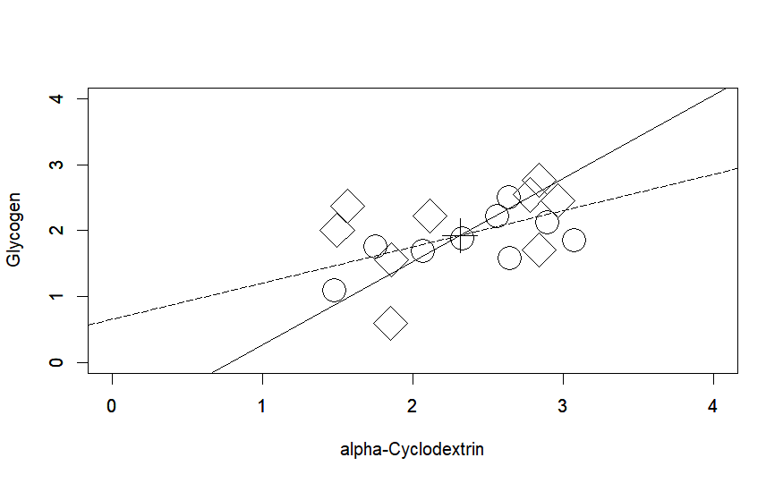

```r
#観測データの平均値を示す点を追加
plot(
  mean(summary_ecoplate$s04), mean(summary_ecoplate$s05), #平均値の計算
  cex = 3, #グラフのタイプの指定, pは散布図
  pch = 3, #マークの種類の指定
  xlim = c(0, 4), #x軸の最小・最大指定
  ylim = c(0, 4), #y軸の最小・最大指定
  xlab = "", ylab = "" #x軸の名前とy軸の名前を空欄にするため（一つ上のグラフの軸名と文字が重ならないため）、""だけで指定する
  #,asp = 1.0
)
```

第1主成分軸上に移したデータをグラフ化する(図8.3B)

```r
#グラフの縦軸用にダミーで値ゼロのベクトルを用意
y_dummy <- rep(0, length(summary_ecoplate[, 1]))
#横軸に第1主成分軸のsite score、縦軸0の散布図を描く
plot(
  y_dummy ~ model02$sites[, 1], #モデル式
  pch = c(1,5)[as.factor(metadata_ecoplate$treatment)], #処理(treatment)の違いをマークの種類の違いに指定
  cex = 3,
  xlim = c(-2, 2), ylim = c(-0.5, 0.5),
  xlab = "New axis",
  ylab = ""
)
par(new = T)
```

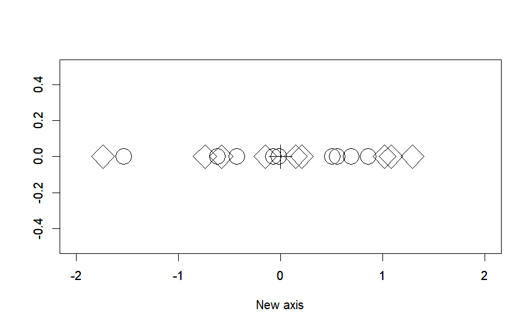

```r
#平均値＝原点(0, 0)を強調するためにマークを追加
plot(
  0.0, 0.0,
  cex = 3,
  pch = 3,
  xlim = c(-2, 2), ylim = c(-0.5, 0.5),
  xlab = "", ylab = ""
)
```

#### 次元削減例をもう一つ

3次元空間上で，2次元へと次元削減した平面とベクトルを描画してみる(Rコードを実行すれば別ウィンドウに表示されますが、このHTML上にはあとから画像を埋め込みました

```r
####Plot 3D data####
library(rgl) #rglパッケージを使います
#エコプレートデータの基質4, 5, 6を使って三次元散布図を描く
plot3d(
  x = summary_ecoplate$s04, y = summary_ecoplate$s05, z = summary_ecoplate$s06,
  xlab = substrate_name[4], ylab = substrate_name[5], zlab = substrate_name[6],
  type = "s",
  size = 3,
  col = c(2, 9)[as.factor(metadata_ecoplate$treatment)]
)
#この3次元データに対して主成分分析を実行
model03 <- summary(capscale(summary_ecoplate[,4:6] ~ 1, distance = "euclidean"))
#PC1-PC2 plane can be defined by the orthogonal vector (i.e, PC3)
#第1主成分軸ー第2主成分軸が張る平面は，この平面と直交するベクトル(すなわち第3主成分軸)で定義可能
PC1_coeff <- model03$species[1:3, 1]
PC2_coeff <- model03$species[1:3, 2]
PC3_coeff <- model03$species[1:3, 3]
#観測データの平均値を計算
new_origin <- c(mean(summary_ecoplate$s04), mean(summary_ecoplate$s05), mean(summary_ecoplate$s06))
#切片の計算
intercept_coeff <- (PC3_coeff %*% new_origin) * -1.0
##第1主成分軸ー第2主成分軸が張る平面の描画(法線ベクトルPC3_coeffと切片で定義される)
planes3d(PC3_coeff[1], PC3_coeff[2], PC3_coeff[3], intercept_coeff, col = "blue", alpha = 0.5)
#第1主成分軸をベクトルとして描画
arrow3d(
  p0 = new_origin,
  p1 = new_origin + PC1_coeff * 0.4,
  s = 1 / 4,
  type = "rotation"
)
#第2主成分軸をベクトルとして描画
arrow3d(
  p0 = new_origin,
  p1 = new_origin + PC2_coeff * 0.4,
  s = 1 / 4,
  type = "rotation"
)
```

あとから上の実行結果として表示されるウィンドウの画像を埋め込んだもの

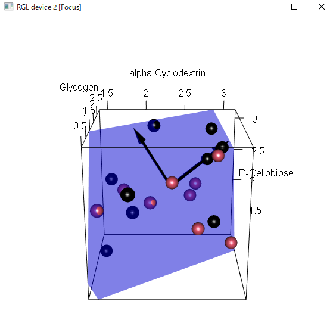

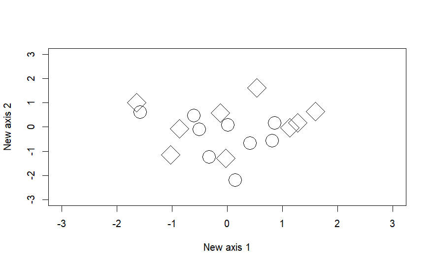

```r
####Reduction to 2D####
plot(
  model03$sites[, 2] ~ model03$sites[, 1], #モデル式
  pch = c(1,5)[as.factor(metadata_ecoplate$treatment)], #処理(treatment)の違いをマークの種類の違いに指定
  cex = 3,
  xlim = c(-3, 3), ylim = c(-3, 3),
  xlab = "New axis 1",
  ylab = "New axis 2"
  #,asp = 1.0
)
```

1次元直線上へ移したデータの可視化(1次元への次元削減)

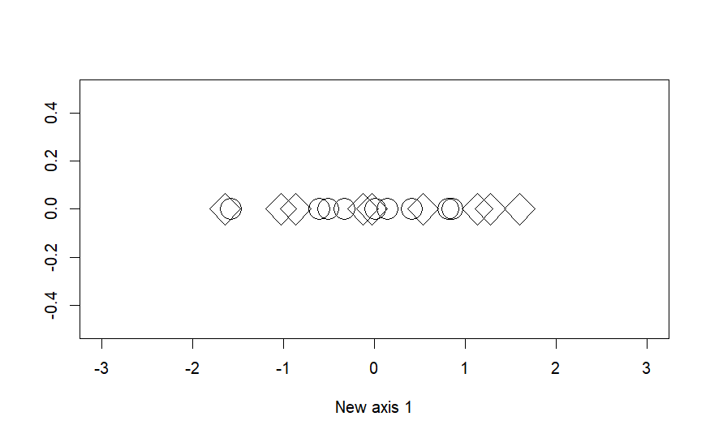

```r
####Reduction to 1D####
y_dummy <- rep(0, length(summary_ecoplate[, 1]))
plot(
  y_dummy ~ model03$sites[, 1],
  pch = c(1,5)[as.factor(metadata_ecoplate$treatment)],
  cex = 3,
  xlim = c(-3, 3), ylim = c(-0.5, 0.5),
  xlab = "New axis 1",
  ylab = ""
)
```

### 8.2 多変量データの可視化１：主成分分析

#### 8.2.1 主成分分析は座標軸の回転を意味する

次のものもHTML上では埋め込み画像として表示されますが、Rスクリプトとして実行すれば別ウィンドウに表示されます

```r
####PCA for 3D data with 3 PC axes####
#3次元散布図
plot3d(
  x = summary_ecoplate$s04, y = summary_ecoplate$s05, z = summary_ecoplate$s06,
  xlab = substrate_name[4], ylab = substrate_name[5], zlab = substrate_name[6],
  type = "s",
  size = 3,
  col = c(2, 9)[as.factor(metadata_ecoplate$treatment)]
)
#3次元データに対する主成分分析
model03 <- summary(capscale(summary_ecoplate[, 4:6] ~ 1, distance = "euclidean"))
#主成分軸の方向を表すベクトルを抽出
PC1_coeff <- model03$species[1:3, 1]
PC2_coeff <- model03$species[1:3, 2]
PC3_coeff <- model03$species[1:3, 3]
new_origin <- c(mean(summary_ecoplate$s04), mean(summary_ecoplate$s05), mean(summary_ecoplate$s06))
intercept_coeff <- (PC3_coeff %*% new_origin) * -1.0
planes3d(PC3_coeff[1], PC3_coeff[2], PC3_coeff[3], intercept_coeff, col = "blue", alpha = 0.5)
#主成分軸のベクトルを重ね合わせ
arrow3d(
  p0 = new_origin,
  p1 = new_origin + PC1_coeff * 0.4,
  s = 1 / 4,
  type = "rotation"
)
arrow3d(
  p0 = new_origin,
  p1 = new_origin + PC2_coeff * 0.4,
  s = 1 / 4,
  type = "rotation"
)
arrow3d(
  p0 = new_origin,
  p1 = new_origin + PC3_coeff * 0.4,
  s = 1 / 4,
  type = "rotation"
)
```

あとから上の実行結果として表示されるウィンドウの画像を埋め込んだもの

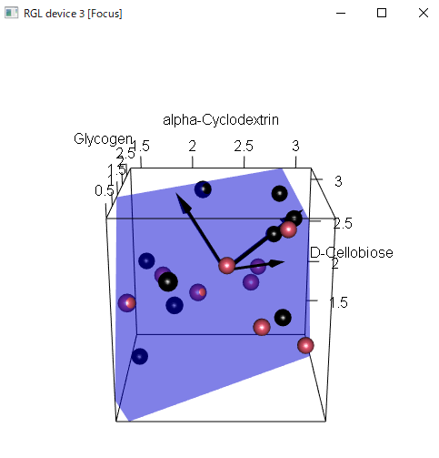

#### 8.2.2 主成分分析のコーディング

31種類の有機炭素基質への反応データに対する主成分分析

```r
####PCA for ecoplate#####
#capscale()関数を使って主成分分析を実行し、summary()関数を用いてその出力結果をまとめ，まとめた結果をオブジェクトPCA_model01に代入(<-)
PCA_model01 <- summary(capscale(summary_ecoplate ~ 1, distance = "euclidean"))
```

```r
#結果を表示してみる: 主成分分析の結果のまとめを保存したオブジェクトの名前, PCA_model01, を書けば中身がみれる
PCA_model01
```

```
Call:
capscale(formula = summary_ecoplate ~ 1, distance = "euclidean")

Partitioning of mean squared Euclidean distance:
              Inertia Proportion
Total           4.674          1
Unconstrained   4.674          1

Eigenvalues, and their contribution to the mean squared Euclidean distance

Importance of components:
                        MDS1   MDS2   MDS3   MDS4    MDS5    MDS6    MDS7    MDS8    MDS9
Eigenvalue            0.9869 0.6444 0.5318 0.5155 0.40574 0.29533 0.26460 0.22005 0.19292
Proportion Explained  0.2112 0.1379 0.1138 0.1103 0.08681 0.06319 0.05661 0.04708 0.04128
Cumulative Proportion 0.2112 0.3490 0.4628 0.5731 0.65994 0.72313 0.77974 0.82682 0.86810
                        MDS10   MDS11   MDS12   MDS13  MDS14   MDS15    MDS16    MDS17
Eigenvalue            0.16005 0.13826 0.12168 0.06727 0.0645 0.02986 0.023712 0.011104
Proportion Explained  0.03425 0.02958 0.02603 0.01439 0.0138 0.00639 0.005074 0.002376
Cumulative Proportion 0.90235 0.93193 0.95797 0.97236 0.9862 0.99255 0.997624 1.000000

Scaling 2 for species and site scores
* Species are scaled proportional to eigenvalues
* Sites are unscaled: weighted dispersion equal on all dimensions
* General scaling constant of scores:  3.219928


Species scores

         MDS1     MDS2      MDS3      MDS4     MDS5      MDS6
s01 -0.274712 -0.19330  0.106203  0.085629 -0.03329 -0.152225
s02  0.042715 -0.17060 -0.029756 -0.094656  0.02136 -0.083495
s03  0.080601 -0.25744 -0.081888  0.198029 -0.09500  0.022155
s04  0.368526  0.14496 -0.295808  0.261178  0.39494  0.024974
s05  0.627787 -0.30164 -0.116183 -0.013603  0.39516 -0.005725
s06 -0.003327 -0.50125  0.187412  0.407381  0.14666  0.004573
s07  0.612858  0.15247  0.364576  0.291182 -0.06206  0.157574
s08  0.431115 -0.07705  0.167742 -0.037470 -0.11409  0.069767
s09  0.190835  0.07554 -0.474748  0.271889 -0.47303 -0.105723
s10  0.259458 -0.01910  0.467278 -0.172241 -0.26677 -0.170656
s11 -0.257191 -0.17395  0.028831 -0.044945  0.07033 -0.164299
```

[output cut: 34 more lines]

```
20150228T1  0.17469 -0.4203 -0.74754  0.15175  0.02181  0.14266
20150228T2 -0.39126 -0.2355 -0.57495 -0.24393  0.35960 -0.01005
20150228T3  0.50722  0.1531  0.73901 -0.17469  1.06940  1.32989
20150507N1  0.82384  1.0266  0.49776  0.34636 -0.65789 -0.18051
20150507N2  0.64832  0.8975  0.12386  0.19921  0.27915  0.36637
20150507N3 -0.14928 -0.7510  0.13698 -1.07049 -0.17716  0.98858
20150507T1  0.29341 -0.5139  0.39391  0.64083  1.07972  0.06165
20150507T2  0.23458 -1.1177  0.06872  0.80228 -0.09451 -0.60262
20150507T3 -1.75319  0.3484  0.54160  0.79279 -0.02502  0.13661
20150703N1  0.82384  1.0266  0.49776  0.34636 -0.65789 -0.18051
20150703N2  0.64832  0.8975  0.12386  0.19921  0.27915  0.36637
20150703N3 -0.14928 -0.7510  0.13698 -1.07049 -0.17716  0.98858
20150703T1  0.29341 -0.5139  0.39391  0.64083  1.07972  0.06165
20150703T2  0.23458 -1.1177  0.06872  0.80228 -0.09451 -0.60262
20150703T3 -1.75319  0.3484  0.54160  0.79279 -0.02502  0.13661
```

```r
#各データの主成分軸上の座標の表示: 主成分分析の結果を保存したオブジェクトの中のsites列にその座標情報がある
PCA_model01$sites
```

```
                  MDS1       MDS2        MDS3        MDS4        MDS5        MDS6
20141216N1 -0.45758140  0.5589816  0.39963568 -0.15099118 -1.03040378 -0.52122280
20141216N2  0.32717188 -0.1525218  0.88592400 -1.20633329  0.06320048 -1.05379587
20141216N3 -0.01943224 -0.4147696 -0.47423580 -0.03095043 -0.99845214 -0.33973601
20141216T1 -0.60153647  0.1765396 -0.38177148 -0.69810122  0.07789807 -0.07955375
20141216T2  0.44787567 -0.7660001  0.28492363 -0.26773655 -1.19329503 -0.20912685
20141216T3 -0.43854264  0.4941251  0.08732414 -1.01599568 -0.06506097  0.19631712
20150228N1 -0.01238718  0.2342721 -0.42322128 -0.49486588  1.19911490 -1.79360415
20150228N2  0.40544811 -0.1486364 -1.23295536  0.95114661 -0.73759170  0.84498703
20150228N3 -0.13702624  0.7408609 -2.08780579 -0.24126057  0.42516627 -0.04694815
20150228T1  0.17469420 -0.4202571 -0.74753547  0.15175172  0.02181335  0.14265754
20150228T2 -0.39125659 -0.2354862 -0.57494902 -0.24393298  0.35960392 -0.01005146
20150228T3  0.50721864  0.1530751  0.73900623 -0.17468846  1.06940217  1.32989432
20150507N1  0.82383657  1.0266292  0.49776363  0.34635514 -0.65788638 -0.18051053
20150507N2  0.64831956  0.8975307  0.12385966  0.19920755  0.27915171  0.36637418
20150507N3 -0.14928157 -0.7509984  0.13698328 -1.07048549 -0.17715574  0.98858487
20150507T1  0.29340572 -0.5139238  0.39391181  0.64083197  1.07971960  0.06165433
20150507T2  0.23458489 -1.1177382  0.06871639  0.80228286 -0.09451101 -0.60262124
20150507T3 -1.75318803  0.3484089  0.54159550  0.79278693 -0.02501594  0.13660989
20150703N1  0.82383657  1.0266292  0.49776363  0.34635514 -0.65788638 -0.18051053
20150703N2  0.64831956  0.8975307  0.12385966  0.19920755  0.27915171  0.36637418
20150703N3 -0.14928157 -0.7509984  0.13698328 -1.07048549 -0.17715574  0.98858487
20150703T1  0.29340572 -0.5139238  0.39391181  0.64083197  1.07971960  0.06165433
20150703T2  0.23458489 -1.1177382  0.06871639  0.80228286 -0.09451101 -0.60262124
20150703T3 -1.75318803  0.3484089  0.54159550  0.79278693 -0.02501594  0.13660989
```

最初の二つの主成分軸に関して可視化→つまり二次元への次元削減

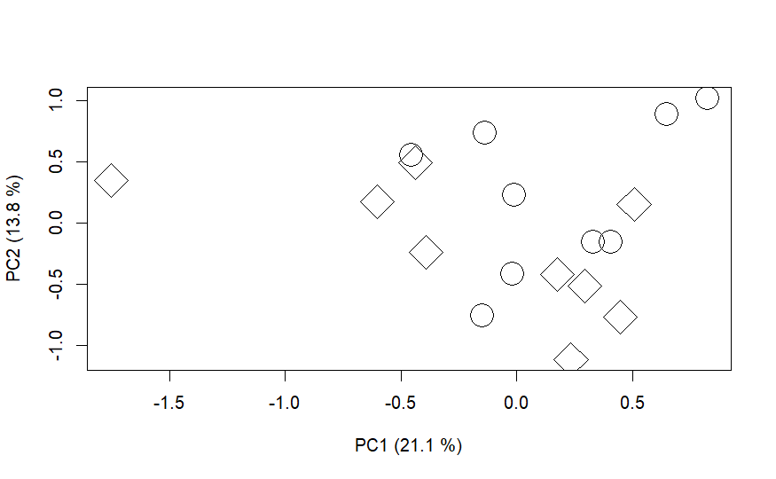

```r
#最初の二つの主成分軸上の座標点をベクトルに格納: 主成分分析の結果を保存したオブジェクトの中のsites列の中で、さらに1列目(第1主成分)と2列目(第2主成分)を抜き出して、それぞれベクトルとしてPC1_01, PC2_01に保存
PC1_01 <- PCA_model01$sites[, 1]
PC2_01 <- PCA_model01$sites[, 2]
#散布図
plot(
  PC2_01 ~ PC1_01,　#モデル式
  cex = 3, pch = c(1, 5)[as.factor(metadata_ecoplate$treatment)],#処理(treatment)の違いを因子に変換すれば，それによって各点のマークを指定できる
  xlab = "PC1 (21.1 %)", ylab = "PC2 (13.8 %)"　#寄与率を軸名の中に含める
)
```

PCAの練習：植物プランクトンデータに対する主成分分析

```r
####PCA for phytoplankton####
#PCAの実行
PCA_model02 <- summary(capscale(species_ryuko_data ~ 1, distance = "euclidean"))
#PCAの結果の表示(この結果を見て、寄与率の確認が必要)
PCA_model02
```

```
Call:
capscale(formula = species_ryuko_data ~ 1, distance = "euclidean")

Partitioning of mean squared Euclidean distance:
              Inertia Proportion
Total           32768          1
Unconstrained   32768          1

Eigenvalues, and their contribution to the mean squared Euclidean distance

Importance of components:
                           MDS1      MDS2      MDS3      MDS4      MDS5      MDS6
Eigenvalue            2.030e+04 9259.0918 1.520e+03 380.60436 2.969e+02 2.396e+02
Proportion Explained  6.195e-01    0.2826 4.638e-02   0.01162 9.061e-03 7.311e-03
Cumulative Proportion 6.195e-01    0.9021 9.485e-01   0.96010 9.692e-01 9.765e-01
                           MDS7      MDS8      MDS9     MDS10     MDS11     MDS12
Eigenvalue            1.863e+02 1.563e+02 1.327e+02 1.155e+02 71.719285 54.020636
Proportion Explained  5.686e-03 4.771e-03 4.051e-03 3.525e-03  0.002189  0.001649
Cumulative Proportion 9.822e-01 9.869e-01 9.910e-01 9.945e-01  0.996690  0.998339
                          MDS13     MDS14
Eigenvalue            3.077e+01 23.658246
Proportion Explained  9.391e-04  0.000722
Cumulative Proportion 9.993e-01  1.000000

Scaling 2 for species and site scores
* Species are scaled proportional to eigenvalues
* Sites are unscaled: weighted dispersion equal on all dimensions
* General scaling constant of scores:  26.02529


Species scores

                                             MDS1       MDS2       MDS3       MDS4
Acanthoceras sp.                        1.356e-01 -0.0436664 -0.0029062  1.977e-01
Acanthoceras zachariasii               -1.948e-02 -0.0499752 -0.1160193 -4.826e-02
Actinastrum hantzschii                  2.131e-02 -0.0234244 -0.0701410  1.524e-02
Anabaena affinis                        2.037e-01  0.0157999 -0.0318410  5.341e-02
Anabaena flos-aquae                     2.411e-02  0.0003644  0.0001992 -2.022e-02
Anabaena macrospora                     5.946e-02  0.0032665 -0.0205286  5.384e-02
Anabaena spiroides                      1.045e-01 -0.0079161 -0.0215709 -1.400e-02
```

[output cut: 235 more lines]

```
20180316_1_ryuko.csv -3.625 -2.5990 -6.5664   1.23009   1.5920  -2.9000
20180316_2_ryuko.csv -2.121 -2.2411 -6.6991  -5.72102   9.2367  13.6944
20181004_1_ryuko.csv  8.054  0.4425 -2.7809   7.29280 -12.4658   4.9112
20181004_2_ryuko.csv  2.486 -1.3234 -6.1101  12.63582  15.3683 -10.6444
20181004_3_ryuko.csv 19.859  2.8392  4.3138 -10.34274   5.4653   1.4873
20181025_1_ryuko.csv  8.213  0.4587 -2.4366   7.72205  -7.4018  -3.9286
20181025_2_ryuko.csv -6.075 24.3806  0.7626  -0.03946   0.3615  -0.1043
20190425_1_ryuko.csv -3.406 -2.9707  6.7105  10.31864   1.8460  15.1547
20190425_2_ryuko.csv -3.220 -3.2612 19.5675   0.01380   1.7572  -5.5855
20190425_3_ryuko.csv -3.377 -2.6516  3.2629  -0.32512  -0.1626   1.7288
20190425_4_ryuko.csv -3.252 -2.9731  4.3755  -3.12966  -2.6109  -6.1808
20190425_5_ryuko.csv -3.083 -2.3292 -1.3169  -1.12684  -1.7799   0.6998
20190520_1_ryuko.csv -3.457 -2.6811 -3.3158 -10.71737   1.2495  -2.9450
20190520_2_ryuko.csv -3.471 -2.4981 -5.5881  -4.45649  -3.2734  -2.1660
20190520_3_ryuko.csv -3.527 -2.5925 -4.1789  -3.35453  -9.1822  -3.2216
```

```r
#主成分軸上の座標の表示
PCA_model02$sites
```

```
                          MDS1       MDS2      MDS3         MDS4        MDS5        MDS6
20180316_1_ryuko.csv -3.625009 -2.5990212 -6.566388   1.23009410   1.5920360  -2.9000447
20180316_2_ryuko.csv -2.120681 -2.2411032 -6.699069  -5.72101759   9.2367417  13.6944305
20181004_1_ryuko.csv  8.054392  0.4424877 -2.780865   7.29279794 -12.4657998   4.9111617
20181004_2_ryuko.csv  2.486019 -1.3233970 -6.110121  12.63582291  15.3683432 -10.6443827
20181004_3_ryuko.csv 19.859039  2.8392409  4.313775 -10.34273688   5.4652619   1.4873411
20181025_1_ryuko.csv  8.213051  0.4586884 -2.436604   7.72204944  -7.4017640  -3.9286448
20181025_2_ryuko.csv -6.074667 24.3805976  0.762634  -0.03945615   0.3615106  -0.1043213
20190425_1_ryuko.csv -3.406251 -2.9707125  6.710470  10.31863801   1.8460152  15.1547408
20190425_2_ryuko.csv -3.219595 -3.2612070 19.567476   0.01380347   1.7571843  -5.5855416
20190425_3_ryuko.csv -3.376515 -2.6515804  3.262944  -0.32511644  -0.1626037   1.7287579
20190425_4_ryuko.csv -3.251831 -2.9731434  4.375454  -3.12965731  -2.6108802  -6.1808305
20190425_5_ryuko.csv -3.082553 -2.3292117 -1.316942  -1.12684110  -1.7799381   0.6998468
20190520_1_ryuko.csv -3.457473 -2.6810952 -3.315780 -10.71736633   1.2494908  -2.9449521
20190520_2_ryuko.csv -3.470543 -2.4980889 -5.588099  -4.45648635  -3.2734198  -2.1659852
20190520_3_ryuko.csv -3.527384 -2.5924541 -4.178886  -3.35452773  -9.1821779  -3.2215758
```

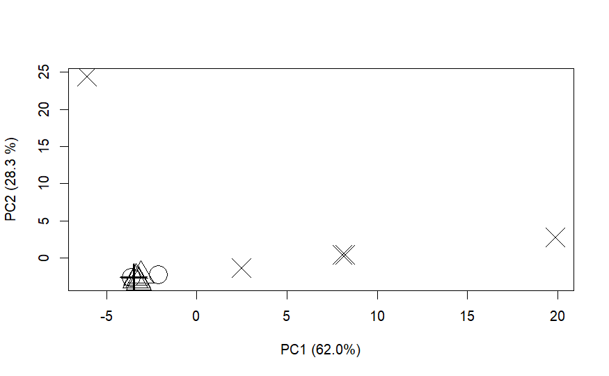

```r
#最初の2軸分の座標情報をベクトルに格納
PC1_02 <- PCA_model02$sites[, 1]
PC2_02 <- PCA_model02$sites[, 2]
#散布図
plot(
  PC2_02 ~ PC1_02,　#モデル式
  cex = 3, pch = as.numeric(as.factor(phyto_metadata$month)),
  xlab = "PC1 (62.0%)", ylab = "PC2 (28.3 %)" #寄与率を軸名の中に書き込む
)
```

#### 8.2.3 主成分分析はすべての次元削減可視化の基盤

主成分分析は主座標分析も含めすべての次元削減可視化の土台ですので，完璧に理解することがとても重要です．とくに、8.2.2の部分に書かれたこーどについては，1行1行の意味を確認しながら実行してみましょう．

#### 8.2.4 主成分分析のスケール依存性

ニューヨークの大気データについて読み込んで前処理

```r
####PCA for airquality data####
data("airquality") #データの読み込み
#基本的な統計量を表示する
summary(airquality)
```

```
     Ozone           Solar.R           Wind             Temp           Month
 Min.   :  1.00   Min.   :  7.0   Min.   : 1.700   Min.   :56.00   Min.   :5.000
 1st Qu.: 18.00   1st Qu.:115.8   1st Qu.: 7.400   1st Qu.:72.00   1st Qu.:6.000
 Median : 31.50   Median :205.0   Median : 9.700   Median :79.00   Median :7.000
 Mean   : 42.13   Mean   :185.9   Mean   : 9.958   Mean   :77.88   Mean   :6.993
 3rd Qu.: 63.25   3rd Qu.:258.8   3rd Qu.:11.500   3rd Qu.:85.00   3rd Qu.:8.000
 Max.   :168.00   Max.   :334.0   Max.   :20.700   Max.   :97.00   Max.   :9.000
 NA's   :37       NA's   :7
      Day
 Min.   : 1.0
 1st Qu.: 8.0
 Median :16.0
 Mean   :15.8
 3rd Qu.:23.0
 Max.   :31.0
```

```r
#欠損データを取り除き、新しいオブジェクトair_dataに格納する
air_data <- na.omit(airquality)
```

データの標準化をしない場合の可視化(図8.9作成用のコード)

```r
#PCAの実行
PCA_model03 <- summary(capscale(air_data[,1:4] ~ 1, distance = "euclidean"))
#PCAの結果の表示(寄与率の確認が必要)
PCA_model03
```

```
Call:
capscale(formula = air_data[, 1:4] ~ 1, distance = "euclidean")

Partitioning of mean squared Euclidean distance:
              Inertia Proportion
Total            9520          1
Unconstrained    9520          1

Eigenvalues, and their contribution to the mean squared Euclidean distance

Importance of components:
                           MDS1     MDS2      MDS3      MDS4
Eigenvalue            8470.5342 996.7931 44.569867 7.6127823
Proportion Explained     0.8898   0.1047  0.004682 0.0007997
Cumulative Proportion    0.8898   0.9945  0.999200 1.0000000
```

[output cut: 130 more lines]

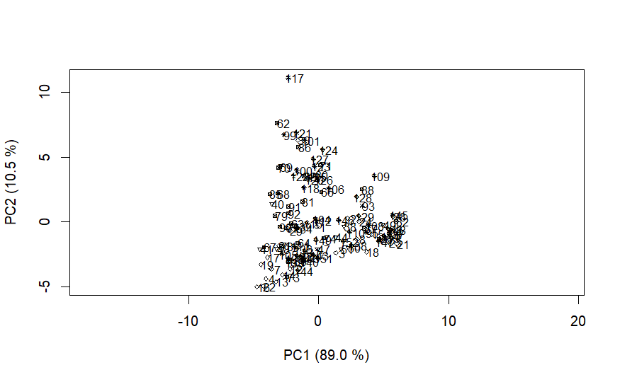

```r
#最初の主成分軸二つについて座標値をベクトルに格納
PC1_03 <- PCA_model03$sites[, 1]
PC2_03 <- PCA_model03$sites[, 2]
#散布図作成
plot(
  PC2_03 ~ PC1_03,#モデル式(Y ~ X)
  cex = 0.5, pch = air_data$Month, #pchの引数としてmonthの値を使う
  xlab = "PC1 (89.0 %)", ylab = "PC2 (10.5 %)",
  asp = 1
)
#散布図上の点のそばに、文字を追加する
text(PC1_03 + 0.5, PC2_03, labels = rownames(air_data), cex = 0.8)
```

データの標準化をする場合の可視化(図8.10作成用のコード)

```r
#scale関数を使ってデータの標準化
air_data2 <- scale(air_data)
#標準化後のデータの基本統計量
summary(air_data2[, 1:4])
```

```
     Ozone            Solar.R             Wind               Temp
 Min.   :-1.2351   Min.   :-1.9506   Min.   :-2.14735   Min.   :-2.1818
 1st Qu.:-0.7242   1st Qu.:-0.7822   1st Qu.:-0.71384   1st Qu.:-0.7128
 Median :-0.3335   Median : 0.2435   Median :-0.06736   Median : 0.1267
 Mean   : 0.0000   Mean   : 0.0000   Mean   : 0.00000   Mean   : 0.0000
 3rd Qu.: 0.5981   3rd Qu.: 0.7756   3rd Qu.: 0.43859   3rd Qu.: 0.7038
 Max.   : 3.7835   Max.   : 1.6368   Max.   : 3.02452   Max.   : 2.0155
```

```r
#標準化されたデータに対してPCを実行
PCA_model04 <- summary(capscale(air_data2[, 1:4] ~ 1, distance = "euclidean"))
#PCAの結果の表示(寄与率の確認が必要)
PCA_model04
```

```
Call:
capscale(formula = air_data2[, 1:4] ~ 1, distance = "euclidean")

Partitioning of mean squared Euclidean distance:
              Inertia Proportion
Total               4          1
Unconstrained       4          1

Eigenvalues, and their contribution to the mean squared Euclidean distance

Importance of components:
                      MDS1   MDS2   MDS3    MDS4
Eigenvalue            2.36 0.8947 0.4757 0.26968
Proportion Explained  0.59 0.2237 0.1189 0.06742
Cumulative Proportion 0.59 0.8136 0.9326 1.00000
```

[output cut: 130 more lines]

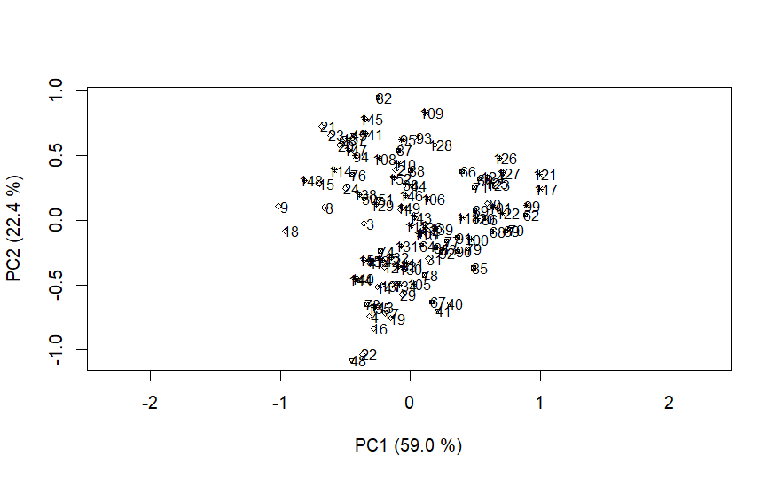

```r
#最初の主成分軸2つの上の座標値をベクトルに格納
PC1_04 <- PCA_model04$sites[, 1]
PC2_04 <- PCA_model04$sites[, 2]
#散布図
plot(
  PC2_04 ~ PC1_04,
  cex = 0.5, pch = air_data$Month,
  xlab = "PC1 (59.0 %)", ylab = "PC2 (22.4 %)",
  asp = 1
)
#文字の追加
text(PC1_04 + 0.05, PC2_04, labels = rownames(air_data), cex = 0.8)
```

標準化はいつもしたほうがよいのか？

```r
#Large variations between variables with the same unit
#個体数が大きく異なる2種類の植物プランクトンの比較
summary(species_ryuko_data$`Fragilaria crotonensis`)
```

```
   Min. 1st Qu.  Median    Mean 3rd Qu.    Max.
  0.000   0.000   2.000   2.533   4.500   8.000
```

```r
summary(species_ryuko_data$`Micrasterias hardyi`)
```

```
   Min. 1st Qu.  Median    Mean 3rd Qu.    Max.
   0.00    0.50    6.00   18.73   28.00   96.00
```

BOX8 R標準の主成分分析用関数を使う場合

```r
####Standard way of PCA####
#標準化しない場合
PCA_s01 <- prcomp(air_data[, 1:4], scale. = F)
#標準化する場合
PCA_s02 <- prcomp(air_data[, 1:4], scale. = T)
#標準化しない場合の結果
summary(PCA_s01)
```

```
Importance of components:
                           PC1     PC2     PC3    PC4
Standard deviation     92.0355 31.5720 6.67607 2.7591
Proportion of Variance  0.8898  0.1047 0.00468 0.0008
Cumulative Proportion   0.8898  0.9945 0.99920 1.0000
```

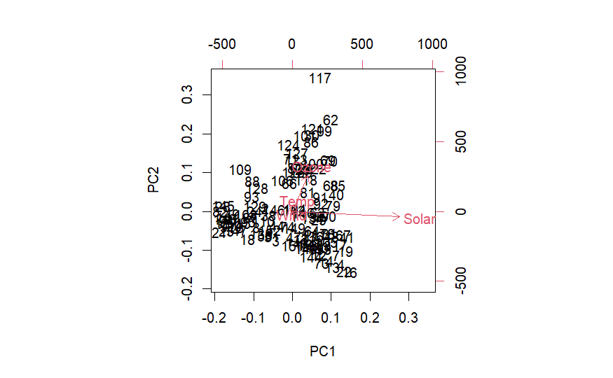

```r
#可視化(標準化無し)
biplot(PCA_s01)
```

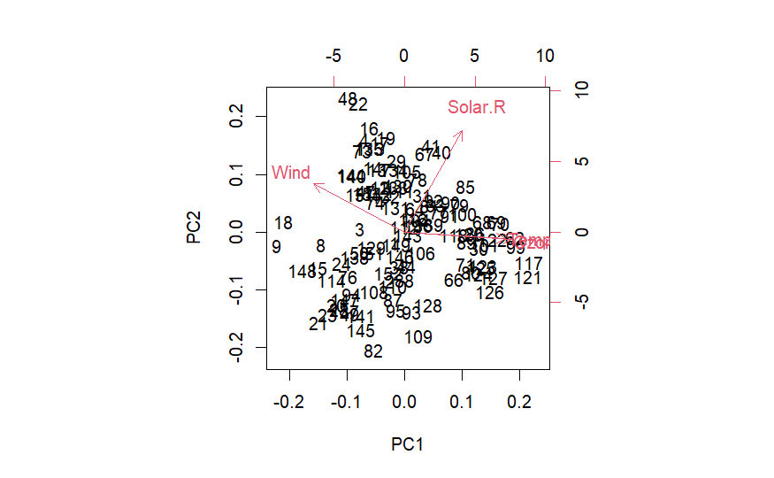

```r
#可視化(標準化有り)
biplot(PCA_s02)
```